# Data processing for individual network

Nguyen Huynh

17 December 2021

Abstract

This script depicts the differential expression analysis with removal of unwanted variation. Subsequently, the importance of covariates to sample variation was evaluated, and significant covariates were then used for identification of prioritized modules. Here, we show the procedure for one representative network (Astrocyte HD). However, the same procedure was applied for all other networks.

```r
# Load necessary libraries
suppressPackageStartupMessages(library(ggplot2))
suppressPackageStartupMessages(library(DESeq2))
suppressPackageStartupMessages(library(EDASeq))
suppressPackageStartupMessages(library(RUVSeq))
suppressPackageStartupMessages(library(factoextra))
suppressPackageStartupMessages(library(reshape2))
suppressPackageStartupMessages(library(DT))
suppressPackageStartupMessages(library(WGCNA))
suppressPackageStartupMessages(library(limma))
suppressPackageStartupMessages(library(SummarizedExperiment))

#
source("helper_functions.R")
options(stringsAsFactors = FALSE)
```

```r
# Results will be saved to the network specific directory
dir.create("results/Astrocyte_HD", recursive = TRUE)
```

## PART 1: Differential expression analysis

#### Data import

```r
# List of ENSEMBL gene ID and corresponding gene names - data curated from ENSEMBL
name2id <- read.table("data/hs95_name2ID.txt", header = TRUE, stringsAsFactors = FALSE)
# Differential expression test
cond1 <- "ESC_derived_CTR_Astro" # CTR samples
cond2 <- "HD_Astro" # Treatment samples

# Read in data
sampleParent <- read.table("data/sampleTable.txt", stringsAsFactors = FALSE, na.strings = "NA")
covParent <- read.table("data/covTable.txt", header = TRUE)
countParent <- read.table("data/deSeq2_RawCounts.txt")
# Genes after the filtering step
keep <- readLines("data/keepGenes.txt")
countParent <- countParent[keep, ]
```

#### Sample selection

```r
# sampleData clean-up ----------------------------------------------------------
sample <- row.names(sampleParent)[c(which(sampleParent$condition == cond1), which(sampleParent$condition == cond2))]
sampleData <- sampleParent[sample,]
### Only get the colnames (covariate) of investigating variances.
sampleData <- sampleData[, which(covParent$take_nottake==1), drop = FALSE]
sampleData$condition <- factor(sampleData$condition, levels=c(cond1, cond2))

# countData clean-up -----------------------------------------------------------
countData <- countParent[, row.names(sampleData)]

# covData clean-up -------------------------------------------------------------
# take_nottake: 0: do not consider; 1: consider
# type        : 1: categorical; 2: continuous
covData <- covParent[which(covParent$take_nottake==1),]
```

### Test: HD_Astro vs ESC_derived_CTR_Astro

```r
if (!all.equal(colnames(sampleData), as.character(covData$covariate))) {
  cat("Error: Check sampleData and covData. They do not have the same covariate strings.")
}

if (!all.equal(colnames(countData), row.names(sampleData))) {
  cat("Error: Check countData and sampleData. They do not have the same column names and row names")
} else {
    # Make DESeq object
    dds <- DESeqDataSetFromMatrix(countData=countData, colData=sampleData, design= ~ condition)
    dds <- DESeq(dds, parallel=FALSE)
} #-End else
```

#### DESeq2 First-Pass

DESeq2 was used to perform data normalization and differential expression analysis on each set of raw expression measures. This is the first pass to create a set of genes whose expressions were not differentially expressed between 2 investigated groups. These genes, referred to as empirical control genes, are then used for downstream RUVseq analysis (Removal of Unwanted Variation).

```r
res1 <- callDiff(cond2, cond1, dds)
res1 <- as.data.frame(res1)
res1 <- res1[order(res1$padj), ]
# Get negative genes for empirical control. In this case we want those genes whose padj values are more than 0.75
empirical <- row.names(res1)[which(res1$padj > 0.75)]
```

The number of empirical control genes used in this experiment is: 2067

#### RUVs

```r
# Upper quartile normalization
set <- betweenLaneNormalization(as.matrix(countData), which="upper")
differences <- makeGroups(sampleData$condition)
```

Pick K

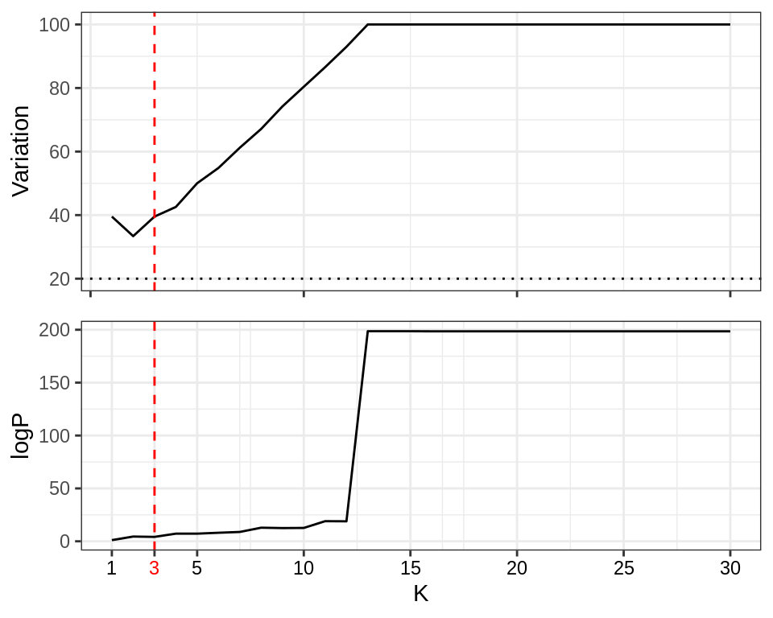

```r
tmp.df <- data.frame(K=character(), Variation = numeric(), logP = numeric())
# Loop through the first 30 Ks
for (i in 1:30) {
  tmp <- RUVs(set, empirical, k=i, differences)
  tmp.pcov <- run_pca(tmp$normalizedCounts)
  tmp.pcaRes <- prcomp(t(log2(tmp$normalizedCounts+1)))
  tmp.eigs <- tmp.pcaRes$sdev^2
  tmp.perc <- tmp.eigs[1]/sum(tmp.eigs)*100
  tmp <- data.frame(K=i, Variation = tmp.perc, logP = tmp.pcov[1,4])
  tmp.df <- rbind(tmp.df, tmp)
}
# Picked K is the first significant K (p < 0.05) that could explain more than 20% of sample variation
KK <- 3
p1 <- ggplot(tmp.df, aes(x=K, y = Variation)) + geom_line() + geom_vline(xintercept = KK, linetype = "dashed", color = "red") + geom_hline(yintercept= 20, linetype= "dotted") +theme_bw() + theme(axis.text.x = element_blank(), axis.title.x = element_blank())
breakers <- unique(c(1,5,10,15,20,25,30,KK))
p2 <- ggplot(tmp.df, aes(x=K, y = logP)) + geom_line() + geom_vline(xintercept = KK, linetype = "dashed", color = "red") + scale_x_continuous(breaks = breakers) + theme_bw() + theme(axis.text.x = element_text(color=ifelse(breakers == KK, "red", "black")))
cowplot::plot_grid(p1, p2, ncol = 1)
```

```r
# Predetermined K from the above for loop
setG <- RUVs(set, empirical, k=KK, differences)
```

#### Data Visualization Before and After RUVSeq

PCA Plot: The plot of principal components (PC). PC1 and PC2 are the two components explaining most of the variance. This plot is useful for visualizing the overall effect of experimental covariates and batch effects. PCA plots were computed on log2-transformed data.

```r
COUNT <- list(as.matrix(countData), set, counts(dds, normalize=TRUE), setG$normalizedCounts)
names(COUNT) <- c("NN", "UQ", "DESeq", "RUV")

logCOUNT <- lapply(COUNT, function(x) log2(x+1))
pcaRes <- lapply(logCOUNT, function(x) prcomp(t(x)))
pcaCoord <- lapply(pcaRes, function(x) x$x)
```

```r
eigs <- lapply(pcaRes, function(x) x$sdev^2)
percentage <- lapply(eigs, function(x) c(x[1]/sum(x), x[2]/sum(x)))
percentage <- lapply(percentage, function(x) round(x*100, 1))
percentage <- lapply(percentage, function(x) paste0("(",x, "%)"))
```

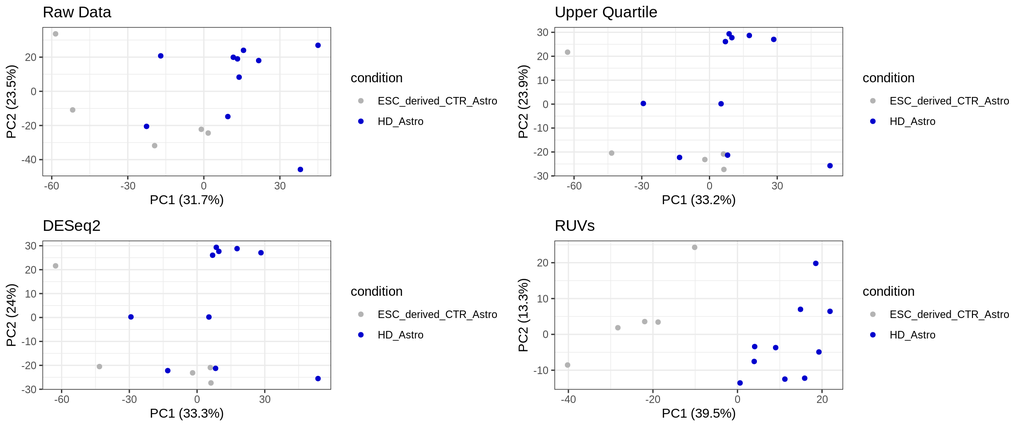

```r
# Define colors
col_val <- c("grey70", "mediumblue")
names(col_val) <- c(cond1, cond2)

p1 <- plotexplorer(pcaCoord[[1]], "Raw Data", percentage[[1]]) + scale_color_manual(values = col_val) + scale_fill_manual(values = col_val)
p2 <- plotexplorer(pcaCoord[[2]], "Upper Quartile", percentage[[2]]) + scale_color_manual(values = col_val) + scale_fill_manual(values = col_val)
p3 <- plotexplorer(pcaCoord[[3]], "DESeq2", percentage[[3]]) + scale_color_manual(values = col_val) + scale_fill_manual(values = col_val)
p4 <- plotexplorer(pcaCoord[[4]], "RUVs", percentage[[4]]) + scale_color_manual(values = col_val) + scale_fill_manual(values = col_val)
cowplot::plot_grid(p1, p2, p3, p4, ncol=2)
```

#### DESeq2 Second-Pass

```r
sampleDataW <-cbind(sampleData, setG$W)
ddsW <- DESeqDataSetFromMatrix(countData = countData, colData = sampleDataW, design = ~ condition)

### compile formula for DESeq2 based on number of K:
      form_string <- ""
      for (w in 1:KK) {
        if (w == KK) {
          form_string <- paste(form_string, "W_", w, sep = "")
        } else {
          form_string <- paste(form_string, "W_", w, " + ", sep = "")
        } # end else
      } # end for

      design(ddsW) <- formula(paste("~", form_string, " + condition", sep = ""))

ddsW <- DESeq(ddsW, parallel = FALSE)
res <- callDiff(cond2, cond1, ddsW)

res$geneName <- plyr::mapvalues(row.names(res), name2id$ensembl_gene_id, name2id$external_gene_name, warn_missing = FALSE)
```

Showing the top 1000 differentially expressed genes

```r
top_res <- res %>% as_tibble %>% select(baseMean, log2FoldChange, padj, geneName) %>% top_n(-1000, padj) %>% as.data.frame
datatable(top_res)
```

|  | baseMean | log2FoldChange | padj | geneName |
| --- | --- | --- | --- | --- |
| 1 | 13265.9839907046 | -0.505251622495893 | 0.000434707136966968 | CD99 |
| 2 | 3865.00612185634 | -0.218473565231264 | 0.00144976086264868 | AK2 |
| 3 | 1429.96406761014 | -0.675881837973646 | 7.77836630031765e-08 | HCCS |
| 4 | 2049.60030702269 | 0.322161147263516 | 0.000793145628528671 | DHX33 |
| 5 | 1650.64689975968 | -0.607894579779109 | 7.42301086527124e-12 | MSL3 |
| 6 | 1792.39544824473 | 0.953253004186133 | 0.000173249687156514 | SOX8 |
| 7 | 1278.33297817095 | 0.408534884126594 | 0.00138621489400256 | ZNF195 |
| 8 | 1577.96582106416 | -0.378407114636686 | 0.00078965789593194 | ARSD |
| 9 | 3644.26104378936 | 0.729924085699929 | 0.000180214353305243 | PROM1 |
| 10 | 2479.35508486008 | -0.241042027739892 | 0.00153565357506264 | CCDC124 |

[output cut: 993 more lines]

## PART 2: WGCNA

An ensemble of all samples were considered for batch correction before WGCNA on each individual network

```r
dds_all <- DESeqDataSetFromMatrix(countData = countParent, colData = sampleParent, design= ~ condition)
sf <- estimateSizeFactorsForMatrix(counts(dds_all))
sizeFactors(dds_all) <- sf
# Transform data
vst_all <- varianceStabilizingTransformation(dds_all)
#
sampleParent$condition3 <- sampleParent$condition
sampleParent$condition3[sampleParent$condition3 %in% c("iPSC_derived_CTR", "ESC_derived_CTR")] <- "CTR"
sampleParent$condition3[sampleParent$condition3 %in% c("iPSC_derived_CTR_Astro", "ESC_derived_CTR_Astro")] <- "CTR_Astro"
vst_corrected2 <- vst_all
# Remove batch effect & make into WGCNA-compatible matrix
data <- removeBatchEffect(assay(vst_corrected2), batch = sampleParent$study_id, design = model.matrix(~sampleParent$condition3))
# Save for later network preservation
saveRDS(data, "./results/batch_corrected.RDS")
mat <- t(data)
```

### Network: Astrocyte HD

#### Choose soft thresholding power

```r
# Subset into specific network based on selected samples
subset <- mat[sample,]
dim(subset)
```

```
## [1]   15 9369
```

```r
# Pick soft thresholding
powers <- c(c(1:20))
sft <- pickSoftThreshold(subset, powerVector = powers, verbose = 5, networkType = "signed", corFnc = "bicor", corOptions = list(use='p', maxPOutliers = 0.1))
```

```
## pickSoftThreshold: will use block size 4775.
##  pickSoftThreshold: calculating connectivity for given powers...
##    ..working on genes 1 through 4775 of 9369
##    ..working on genes 4776 through 9369 of 9369
##    Power SFT.R.sq  slope truncated.R.sq mean.k. median.k. max.k.
## 1      1  0.00123  2.890          0.976  4690.0    4690.0   4830
## 2      2  0.01110  1.090          0.763  2730.0    2710.0   3150
## 3      3  0.01620 -0.521          0.617  1760.0    1720.0   2370
## 4      4  0.09830 -0.780          0.626  1200.0    1160.0   1900
## 5      5  0.23700 -0.941          0.693   866.0     815.0   1570
## 6      6  0.39000 -1.070          0.755   646.0     591.0   1340
## 7      7  0.52700 -1.160          0.813   496.0     440.0   1150
## 8      8  0.61100 -1.230          0.845   390.0     333.0   1010
## 9      9  0.66800 -1.280          0.867   312.0     256.0    894
## 10    10  0.69200 -1.350          0.870   254.0     200.0    797
## 11    11  0.72200 -1.390          0.884   210.0     158.0    716
## 12    12  0.73100 -1.430          0.886   175.0     126.0    647
## 13    13  0.75000 -1.450          0.899   147.0     102.0    587
## 14    14  0.75600 -1.480          0.902   125.0      82.8    536
## 15    15  0.76400 -1.510          0.908   107.0      67.7    491
## 16    16  0.77300 -1.520          0.914    92.7      55.8    451
## 17    17  0.78300 -1.540          0.923    80.5      46.2    416
## 18    18  0.78900 -1.550          0.929    70.4      38.6    384
## 19    19  0.79200 -1.570          0.932    61.8      32.4    356
## 20    20  0.79800 -1.580          0.938    54.6      27.3    331
```

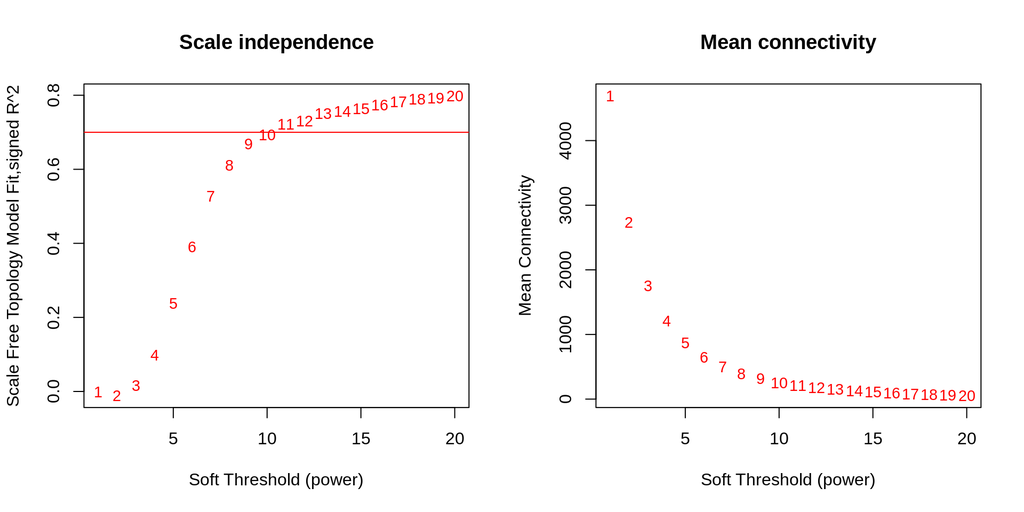

```r
par(mfrow=c(1,2))
cex1 = 0.9
# Scale-free topology fit index as a function of the soft-thresholding power
plot(
  sft$fitIndices[, 1],
  -sign(sft$fitIndices[, 3]) * sft$fitIndices[, 2],
  xlab = "Soft Threshold (power)",
  ylab = "Scale Free Topology Model Fit,signed R^2",
  type = "n",
  main = paste("Scale independence")
)
#
text(
  sft$fitIndices[, 1],
  -sign(sft$fitIndices[, 3]) * sft$fitIndices[, 2],
  labels = powers,
  cex = cex1,
  col = "red"
)
#
abline(h = 0.7, col = "red")
#
#
#
# Mean connectivity as a function of the soft-thresholding power
#
plot(
  sft$fitIndices[, 1],
  sft$fitIndices[, 5],
  xlab = "Soft Threshold (power)",
  ylab = "Mean Connectivity",
  type = "n",
  main = paste("Mean connectivity")
)
text(
  sft$fitIndices[, 1],
  sft$fitIndices[, 5],
  labels = powers,
  cex = cex1,
  col = "red"
)
```

#### TOM

```r
# Pick power
power <- 11
# Calculate TOM
TOM <- TOMsimilarityFromExpr(datExpr = subset, networkType = "signed", TOMType = "signed", power = power, corType = "bicor", maxPOutliers = 0.1)
```

```
## TOM calculation: adjacency..
## ..will not use multithreading.
##  Fraction of slow calculations: 0.000000
## ..connectivity..
## ..matrix multiplication (system BLAS)..
## ..normalization..
## ..done.
```

```r
# Save for later calculation
saveRDS(TOM,"./results/Astrocyte_HD/TOM.RDS")
dissTOM <- 1 - TOM
```

```r
# Create modules of genes by average linkage hierachical clustering based on dissimilarity between genes
geneTree <- hclust(as.dist(dissTOM), method = "average")
modules <-
  cutreeDynamic(
    dendro = geneTree,
    distM = dissTOM,
    deepSplit = 1,
    pamRespectsDendro = FALSE,
    minClusterSize = 50
  )
```

```
##  ..cutHeight not given, setting it to 0.992  ===>  99% of the (truncated) height range in dendro.
##  ..done.
```

```r
moduleColors <- labels2colors(modules)
```

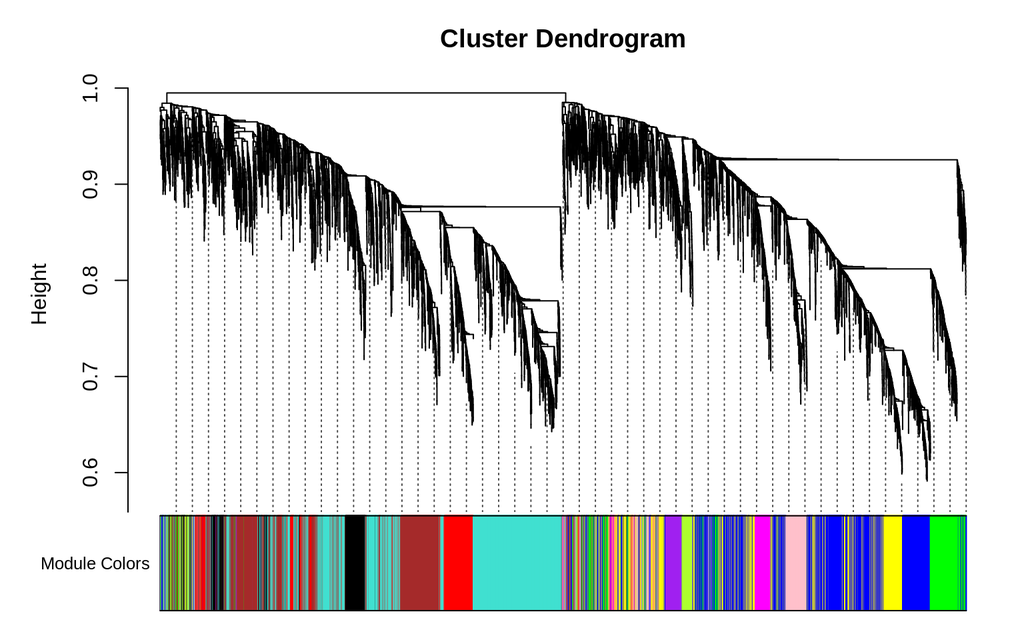

```r
plotDendroAndColors(
  geneTree,
  moduleColors,
  "Module Colors",
  dendroLabels = FALSE,
  hang = 0.01,
  addGuide = TRUE,
  guideHang = 0.05,
  main = "Cluster Dendrogram"
)
```

```r
MEList <- moduleEigengenes(subset, colors = moduleColors)
MEs <- MEList$eigengenes
df <- data.frame(geneID=colnames(subset), moduleColor = moduleColors)
df$geneName <- plyr::mapvalues(df$geneID, name2id$ensembl_gene_id, name2id$external_gene_name, warn_missing = F)
write.table(df, "./results/Astrocyte_HD/geneModuleMembership.txt", row.names = F, col.names = T, quote = F, sep = "\t")
write.table(as.data.frame(MEs), "./results/Astrocyte_HD/ModuleEigengene.txt", row.names = T, col.names = NA, quote = F, sep = "\t")
```

#### Correlation matrix

Calculation of biweight midcorrelations and associated p-values

```r
correlation_mat <- bicorAndPvalue(subset, use = "pairwise.complete.obs", maxPOutliers = 0.1)
saveRDS(correlation_mat, "./results/Astrocyte_HD/bicor.RDS")
```